# Odds Compiler Assessment

Nikolas Neves de Figueiredo  
2026-01-13

# General Sportsbook Knowledge

**1.** What is the overround (payback) for this NBA market and what does this signify?

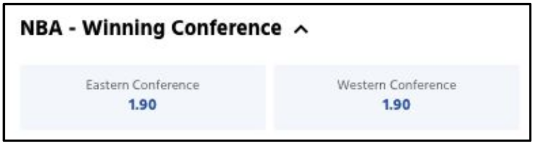

Figure 1: NBA market odds used to calculate overround

```r
knitr::include_graphics("Fig/NBA.png")
```

**Answer:**
$$P_{imp}(\text{East}) = \frac{1}{\text{Odd}} = \frac{1}{1.9} = 0.5263158$$

$$P_{imp}(\text{East}) = P_{imp}(\text{West})
\hspace{10mm} \text{So} \hspace{10mm}
P_{imp}(\text{East}) + P_{imp}(\text{West}) = 1.052632$$
$$\text{Overround}= 1.052632 - 1 = 0.0526316$$
$$\text{Payback} = \frac{1}{1.052632} = 0.9499996 \approx 95\%$$
*Overround, or vig, is the margin that the bookmaker builds into the odds to ensure long-term profitability. In this case, the overround is equal to 5%, so the bookmaker pays back 95% of the total value received in bets to the bettors.*

**2.** The balanced line for Alcaraz v Berritini opens at **20.5** total games and closes at **22.5** at event start. Which selection has the most closing line value (CLV):

1. Over 20.5
2. Under 20.5
3. Over 22.5
4. Under 22.5

**Answer:** *The correct answer is (a) Over 20.5. This selection has the most closing line value because the total games line moved up from 20.5 to 22.5. A bettor who took Over 20.5 beat the closing line by two games, which indicates positive CLV.*

**3.** According to these odds, what is the most likely outcome of the match?

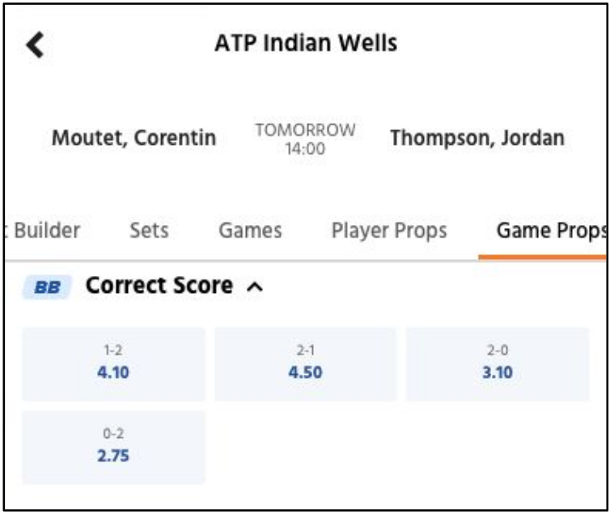

Figure 2: ATP market odds used to determine most likely outcome

```r
knitr::include_graphics("Fig/ATP Indian.png")
```

**Answer:**
$$P_{imp}(\text{1-2}) = \frac{1}{4.1} = 0.2439024$$
$$P_{imp}(\text{2-1}) = \frac{1}{4.5} = 0.2222222$$
$$P_{imp}(\text{2-0}) = \frac{1}{3.1} = 0.3225806$$
$$P_{imp}(\text{0-2}) = \frac{1}{2.75} = 0.3636364$$

*Even this probabilities has the overrond into then. The most likely outcome of the match is a 0-2 win for the second player, as it has the highest implied probability of approximately 36.36%.*

# Modelling - Part 1

Several operators are using Early Payout (EP) as a promotional tool to attract customers.  
This section proposes a model that outputs the expected net profit of the bookmaker as a function of the chosen point differential for NBA Early Payout.

**Answer:**

*Definition of variables and assumptions*

- **T**: *total turnover in the considered market. Assumed value:* $T = 1,000,000$
- **θ**: *fraction of total turnover eligible for the Early Payout promotion, with* $0 < θ < 1$. *Assumed value:* $θ = 0.40$
- **m**: *average market overround. Assumed value:* $m = 0.05$
- **H**: *team win probability. Assumed value:* $H = 0.55$
- **o**: *average decimal odds. Assumed value:* $o = 1.82$
- **x**: *point differential that triggers the Early Payout*
- **C(x)**: *expected cost associated with the Early Payout*
- **L(x)**: *event that the team leads the game by at least* $x$ *points at some point*
- **R(x)**: *risk function associated with the Early Payout promotion*

*Consider the following expressions:*

*The expected bookmaker profit without Early Payout is given by:*

- $f_0 = m · T = 0.05 · 1,000,000 = 50,000$

*A fraction of the total turnover is eligible for the promotion:*

- $T_{EP} = θ · T = 0.40 · 1,000,000 = 400,000$

*The unit cost per incorrectly settled Early Payout is:*

- $u = o − 1 = 1.82 − 1 = 0.82$

*The expected net profit with Early Payout is defined as:*

- $f(x) = f_0 − C(x)$

*The expected cost of Early Payout is modeled as the product of:*

1. *Turnover exposed to the promotion*
2. *Sporting risk of incorrectly triggering the Early Payout*
3. *Unit cost per bet*

*Thus:*

- $C(x) = T_{EP} · R(x) · u$

*Define the risk event as:*

- $R(x) = P(L(x) ∩ H^c)$

*Since, as the point difference $x$ increases, it becomes increasingly unlikely to reverse the score, and this effect is stronger for smaller margins around the mean score, stabilizing for larger differences, possibly after the third quartile, it is intuitively reasonable to use the exponential distribution to model this event. This risk is assumed to decay exponentially with the point differential:*

- $R(x) = α · e^{(−βx)}$

*where:*

- $α > 0$ *represents the maximum risk for small leads*
- $β > 0$ *controls the speed at which the risk decays as* $x$ *increases*

```r
load_nba_data <- function(path = getwd(),
                          seasons = seq(1996, 2024),
                          data = c("datanba", "nbastats", "pbpstats", "shotdetail",
                                   "cdnnba", "nbastatsv3", "matchups"),
                          seasontype = 'rg',
                          league = 'nba',
                          in_memory = FALSE,
                          untar = FALSE){

  path <- normalizePath(path, mustWork = FALSE)

  if (length(data) > 1 & in_memory){
    stop("Parameter in_memory=True available only when loading a single data type")
  }

  if(seasontype == 'rg'){
    df <- expand.grid(data, seasons)
    need_data <- paste(df$Var1, df$Var2, sep = "_")
  } else if(seasontype == 'po'){
    df <- expand.grid(data, 'po', seasons)
    need_data <- paste(df$Var1, df$Var2, df$Var3, sep = "_")
  } else {
    df_rg <- expand.grid(data, seasons)
    df_po <- expand.grid(data, 'po', seasons)
    need_data <- c(paste(df_rg$Var1, df_rg$Var2, sep = "_"),
                   paste(df_po$Var1, df_po$Var2, df_po$Var3, sep = "_"))
  }

  if(tolower(league) == 'wnba'){
    need_data <- sapply(need_data, function(x){paste0('wnba_', x)}, USE.NAMES = FALSE)
  }

  temp <- tempfile()
  download.file("https://raw.githubusercontent.com/shufinskiy/nba_data/main/list_data.txt", temp)
  f <- readLines(temp)
  unlink(temp)

  v <- unlist(strsplit(f, "="))
  name_v <- v[seq(1, length(v), 2)]
  element_v <- v[seq(2, length(v), 2)]
  need_name <- name_v[name_v %in% need_data]
  need_element <- element_v[name_v %in% need_data]

  if (in_memory) df <- data.frame()

  for(i in seq_along(need_element)){
    if (in_memory){
      tmp <- tempfile(fileext = ".tar.xz")
      download.file(need_element[i], tmp, mode = "wb")
      td <- tempdir()
      untar(tmp, exdir = td)
      csv <- list.files(td, pattern = "\\.csv$", full.names = TRUE)
      df <- rbind(df, read.csv(csv))
      unlink(c(tmp, csv))
    } else {
      destfile <- paste0(path, '/', need_name[i], ".tar.xz")
      download.file(need_element[i], destfile)
      if(untar){
        untar(destfile, exdir = path)
        unlink(destfile)
      }
    }
  }

  if (in_memory) return(df)
}

pbp <- load_nba_data(
  data = "pbpstats",
  seasons = 2018:2023,
  seasontype = "rg",
  in_memory = TRUE
)

pbp_proc <- pbp %>%
  filter(!is.na(STARTSCOREDIFFERENTIAL)) %>%
  mutate(
    lead = abs(STARTSCOREDIFFERENTIAL),
    leader = ifelse(STARTSCOREDIFFERENTIAL > 0, "team", "opp")
  )

final_result <- pbp_proc %>%
  group_by(GAMEID) %>%
  arrange(PERIOD, ENDTIME) %>%
  summarise(
    final_diff = last(STARTSCOREDIFFERENTIAL),
    final_win_team = ifelse(final_diff > 0, 1, 0),
    .groups = "drop"
  )

pbp_proc <- pbp_proc %>%
  left_join(final_result, by = "GAMEID") %>%
  mutate(
    win = ifelse(
      (leader == "team" & final_win_team == 1) |
      (leader == "opp"  & final_win_team == 0),
      1, 0
    )
  )

risk_df <- pbp_proc %>%
  filter(lead > 0, lead <= 25) %>%
  group_by(lead) %>%
  summarise(
    p_win = mean(win),
    R = 1 - p_win,
    n = n(),
    .groups = "drop"
  ) %>%
  filter(R > 0)


nls_fit <- nls(
  R ~ alpha * exp(-beta * lead),
  data = risk_df,
  start = list(alpha = 0.6, beta = 0.1),
  weights = n
)

alpha_hat <- coef(nls_fit)["alpha"]
beta_hat  <- coef(nls_fit)["beta"]

cat("alpha =", alpha_hat, "\n",
    "beta  =", beta_hat, "\n")
```

```
alpha = 0.4929904
 beta  = -0.0006794735
```

*Therefore, the expected net profit of the bookmaker under the Early Payout promotion is:*

- $f(x) = f_0 − T_{EP} · u · α · e^{(−βx)}$

*This function explicitly shows how the Early Payout threshold* x *controls promotional cost and expected profitability.*

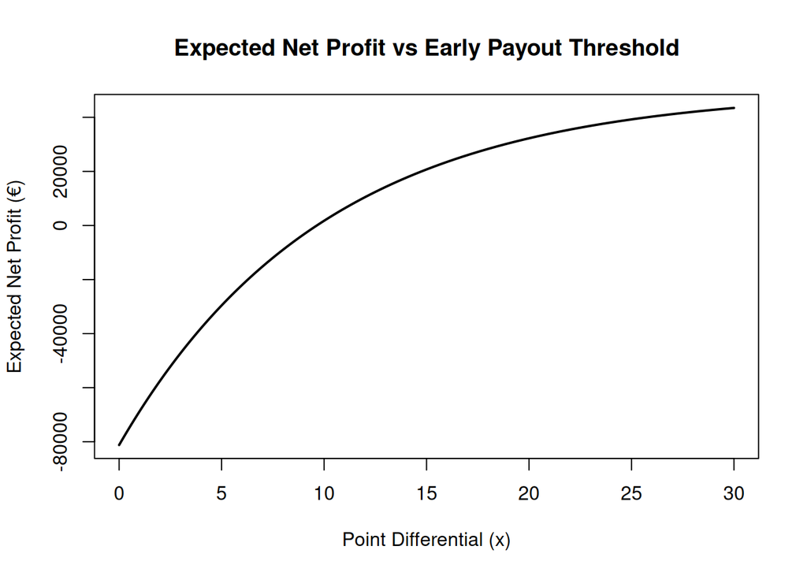

```r
# Parameters
T      <- 1000000
theta  <- 0.40
m      <- 0.05
alpha  <- 0.40
beta   <- 0.10
o      <- 1.82
u      <- o - 1

# Expected profit function with Early Payout
f <- function(x) {
  m * T - T * theta * alpha * u * exp(-beta * x)
}


x <- seq(0, 30, by = 0.1)
profit <- f(x)


plot(
  x, profit,
  type = "l",
  lwd = 2,
  xlab = "Point Differential (x)",
  ylab = "Expected Net Profit (€)",
  main = "Expected Net Profit vs Early Payout Threshold"
)
```

# Modelling - Part 2

Let’s assume that a fake “BetMGM Football Cup” is planned to be played next week between England, France, Germany, Netherlands. Assume all players for each country are healthy throughout, matches are played on neutral site, and each team plays each other once (3 rounds of matches). 3 Points are awarded for a win, 1 point for a draw. Price the following markets in decimal odds:

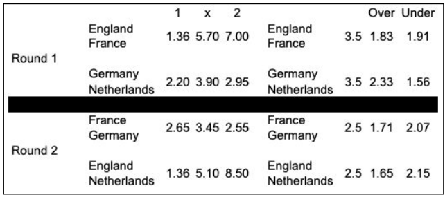

Figure 3: Football Cup teams data used to price the markets

```r
knitr::include_graphics("Fig/football cup.png")
```

**Answer:** *First, I calculate the implied probabilities from the odds provided in the figure.*

```r
# Create the odds table from the figure
odds <- data.frame(
  Round = c("R1", "R1", "R2", "R2"),
  H_team = c("England", "Germany","France", "England"),
  A_team = c("France","Netherlands","Germany","Netherlands"),
  Home = c(1.36, 2.20, 2.65, 1.36),
  Draw = c(5.70, 3.90, 3.45, 5.10),
  Away = c(7.00, 2.95, 2.55, 8.50),
  Line = c(3.50, 3.50, 2.50, 2.50),
  Over = c(1.83, 2.33, 1.71, 1.65),
  Under = c(1.91, 1.56, 2.07, 2.15)
)

Probs <- odds |>
  mutate(
    Home = 1 / Home,
    Draw = 1 / Draw,
    Away = 1 / Away,
    Over = 1 / Over,
    Under = 1 / Under,
    Total_Prob = Home + Draw + Away,
    Total_Line = Over + Under,
    Home = round(Home / Total_Prob, 3),
    Draw = round(Draw / Total_Prob, 3),
    Away = round(Away / Total_Prob, 3),
    Over = round(Over / Total_Line, 3),
    Under = round(Under / Total_Line, 3)
  )
  kable(Probs, caption = "Implied Probabilities for Football Cup Matches")
```

Table 1: Implied Probabilities for Football Cup Matches

| Round | H_team | A_team | Home | Draw | Away | Line | Over | Under | Total_Prob | Total_Line |
| --- | --- | --- | --- | --- | --- | --- | --- | --- | --- | --- |
| R1 | England | France | 0.698 | 0.167 | 0.136 | 3.5 | 0.511 | 0.489 | 1.053590 | 1.070008 |
| R1 | Germany | Netherlands | 0.433 | 0.244 | 0.323 | 3.5 | 0.401 | 0.599 | 1.049939 | 1.070210 |
| R2 | France | Germany | 0.356 | 0.274 | 0.370 | 2.5 | 0.548 | 0.452 | 1.059370 | 1.067887 |
| R2 | England | Netherlands | 0.701 | 0.187 | 0.112 | 2.5 | 0.566 | 0.434 | 1.049020 | 1.071177 |

*Now, using ELO rating, I deduce which team’s strength*

```r
# Elo win probability
elo_prob <- function(Ei, Ej) {
  1 / (1 + 10^(-(Ei - Ej) / 400))
}

elo_diff <- function(p) {
  400 * log10(p / (1 - p))
}

matches <- Probs |>
  mutate(
    Team_A = H_team,
    Team_B = A_team,
    P_A_win = Home,
    Elo_diff = elo_diff(P_A_win)
  ) |>
  select(Team_A, Team_B, P_A_win, Elo_diff)

# Baseline Elo
elo <- c(
  Netherlands = 1500,
  Germany     = 1500,
  France      = 1500,
  England     = 1500
)

# Vetores auxiliares
elo_adjustment <- elo * 0
games_played  <- elo * 0

# Loop simples sobre os jogos
for (i in 1:nrow(matches)) {

  A <- matches$Team_A[i]
  B <- matches$Team_B[i]
  d <- matches$Elo_diff[i]

  elo_adjustment[A] <- elo_adjustment[A] + d
  elo_adjustment[B] <- elo_adjustment[B] - d

  games_played[A] <- games_played[A] + 1
  games_played[B] <- games_played[B] + 1
}

# Elo final = baseline + média dos ajustes
elo <- sort((elo + elo_adjustment / games_played), decreasing = TRUE)

kable(elo, caption = "Final Elo Ratings for Football Cup Teams")
```

Table 2: Final Elo Ratings for Football Cup Teams

|  | x |
| --- | --- |
| England | 1646.779 |
| Germany | 1528.068 |
| Netherlands | 1449.410 |
| France | 1375.743 |

**1**. Round 3 match odds

$$P(i\, \text{beats}\, j) = \frac{1}{1+10^{-\frac{E_i-E_j}{400}}}$$

*In Round 3, we have two matches: England vs Germany and France vs Netherlands, so:*

```r
mean(Probs$Draw)
```

```
[1] 0.218
```

```r
# Match 1: England vs Germany
p_E_elo <- elo_prob(elo["England"], elo["Germany"])

p_E <- round(((1 - 0.22) * p_E_elo), 3)
p_D1 <- 0.220
p_G <- round(((1 - 0.22) * (1 - p_E_elo)), 3)

odd_E <- round(1/(p_E * 1.05),3)
odd_D1 <- round(1/(p_D1 * 1.05),3)
odd_G <- round(1/(p_G * 1.05),3)

# Match 2: France vs Netherlands
p_F_elo <- elo_prob(elo["France"], elo["Netherlands"])

p_F <- round(((1 - 0.22) * p_F_elo), 3)
p_D2 <- 0.220
p_N <- round(((1 - 0.22) * (1 - p_F_elo)), 3)

odd_F <- round(1/(p_F * 1.05),3)
odd_D2 <- round(1/(p_D2 * 1.05),3)
odd_N <- round(1/(p_N * 1.05),3)


odds_est <- data.frame(
  Round       = c("R3", "R3"),
  H_team      = c("England", "France"),
  A_team      = c("Germany","Netherlands"),
  `Home Prob` = c(p_E, p_F),
  `Draw Prob` = c(p_D1, p_D2),
  `Away Prob` = c(p_G, p_N),
  `Home Odds` = c(odd_E, odd_F),
  `Draw Odds` = c(odd_D1, odd_D2),
  `Away Odds` = c(odd_G, odd_N)
)
kable(odds_est, caption = "Estimated Odds for Round 3 Matches")
```

Table 3: Estimated Odds for Round 3 Matches

|  | Round | H_team | A_team | Home.Prob | Draw.Prob | Away.Prob | Home.Odds | Draw.Odds | Away.Odds |
| --- | --- | --- | --- | --- | --- | --- | --- | --- | --- |
| England | R3 | England | Germany | 0.518 | 0.22 | 0.262 | 1.839 | 4.329 | 3.635 |
| France | R3 | France | Netherlands | 0.309 | 0.22 | 0.471 | 3.082 | 4.329 | 2.022 |

**2.** Tournament Winner

```r
# Input probabilities per round (given)
df <- data.frame(
  Team = c("England", "Germany", "Netherlands", "France"),
  R1   = c(0.698, 0.433, 0.323, 0.136),
  R2   = c(0.701, 0.370, 0.112, 0.356),
  R3   = c(0.518, 0.262, 0.471, 0.309)
)

# Overround
margin <- 1.05

# Build table
table_final <- df |>
  mutate(
    Sum_Prob     = R1 + R2 + R3,
    Points_Total = round(3 * Sum_Prob, 3)
  ) |>
  mutate(
    Prob_Fair = Points_Total / sum(Points_Total),
    Prob_Mkt  = Prob_Fair * margin,
    Odds      = round(1 / Prob_Mkt, 2),
    Prob      = round(Prob_Fair, 2)
  ) |>
  select(
    Team, R1, R2, R3,
    Points_Total,
    Prob,
    Odds
  )

# Display table
kable(
  table_final,
  caption = "Tournament Winner – Expected Points, Probabilities and Odds"
)
```

Table 4: Tournament Winner – Expected Points, Probabilities and Odds

| Team | R1 | R2 | R3 | Points_Total | Prob | Odds |
| --- | --- | --- | --- | --- | --- | --- |
| England | 0.698 | 0.701 | 0.518 | 5.751 | 0.41 | 2.33 |
| Germany | 0.433 | 0.370 | 0.262 | 3.195 | 0.23 | 4.19 |
| Netherlands | 0.323 | 0.112 | 0.471 | 2.718 | 0.19 | 4.93 |
| France | 0.136 | 0.356 | 0.309 | 2.403 | 0.17 | 5.58 |

**3.** Highest Scoring Team

*In this case, we can establish the expected number of goals for each team based on their relative strength. Assume that, according to the ELO rating, teams with higher ratings are expected to score more goals. Thus, stronger teams are assigned higher average goals per match.*

*Let the expected goals per match be chosen arbitrarily to reflect relative team strength. These values are then multiplied by the number of matches played (three), and a small normally distributed noise term is added to introduce randomness into the process.*

*Formally, the expected total goals for each team are defined as:*

$$\begin{align*}
\text{England} &= 2.0 \times 3 + \varepsilon, \\
\text{Germany} &= 1.8 \times 3 + \varepsilon, \\
\text{Netherlands} &= 1.1 \times 3 + \varepsilon, \\
\text{France} &= 0.6 \times 3 + \varepsilon,
\end{align*}$$

*where*
$$\varepsilon_i \sim \mathcal{N}(0, 0.01)$$
*represents a small random noise added to each team’s total goals in order to avoid deterministic outcomes.*

*The average total goals for each team are then calculated as follows:*

```r
G_eng  = 2.0 * 3 + rnorm(1,0,0.01)
G_ger  = 1.8 * 3 + rnorm(1,0,0.01)
G_net  = 1.1 * 3 + rnorm(1,0,0.01)
G_fra  = 0.6 * 3 + rnorm(1,0,0.01)

Goals <- data.frame(
  Team = c("England", "Germany", "Netherlands", "France"),
  Expected_Goals = round(c(G_eng, G_ger, G_net, G_fra), 2),
  Probs = round(c(G_eng, G_ger, G_net, G_fra) / sum(c(G_eng, G_ger, G_net, G_fra)), 3),
  Odds = round(1 / (c(G_eng, G_ger, G_net, G_fra) / sum(c(G_eng, G_ger, G_net, G_fra)) * 1.05), 2)
)
kable(Goals, caption = "Highest Scoring Team – Expected Goals, Probabilities and Odds")
```

Table 5: Highest Scoring Team – Expected Goals, Probabilities and Odds

| Team | Expected_Goals | Probs | Odds |
| --- | --- | --- | --- |
| England | 5.99 | 0.363 | 2.62 |
| Germany | 5.40 | 0.327 | 2.91 |
| Netherlands | 3.32 | 0.201 | 4.74 |
| France | 1.80 | 0.109 | 8.73 |

**4.** England To Win All Games

$$P(\text{England wins all games})= 0.698 \cdot 0.701 \cdot 0.518 \approx 0.253 \longrightarrow Odds_{Yes} = 3.95$$
$$P(\text{England wins all games})^C= 1- 0.253 = 0.747 \longrightarrow Odds_{No} = 1.34$$

**5.** Tournament Goal Total for England

```r
# Probabilities using Poisson distribution
p_under <- ppois(3, 3.48)
p_over <- 1 - p_under

# Output
Odds_Over_Under <- data.frame(
  Market = c("Under 3.5", "Over 3.5"),
  Probability = round(c(p_under, p_over), 4),
  Odds = round(c((1/p_under*1.05), (1/p_over*1.05)), 2)
)
kable(Odds_Over_Under, caption = "Odds for England Tournament Goal Total")
```

Table 6: Odds for England Tournament Goal Total

| Market | Probability | Odds |
| --- | --- | --- |
| Under 3.5 | 0.541 | 1.94 |
| Over 3.5 | 0.459 | 2.29 |

**6.** Total Saves in the tournament

```r
p_under <- ppois(17, 18)
p_over <- 1 - p_under

# Output
Odds_Over_Under <- data.frame(
  Market = c("Under 17.5", "Over 17.5"),
  Probability = round(c(p_under, p_over), 4),
  Odds = round(c((1/p_under*1.05), (1/p_over*1.05)), 2)
)
kable(Odds_Over_Under, caption = "Odds for Total Saves in the tournament")
```

Table 7: Odds for Total Saves in the tournament

| Market | Probability | Odds |
| --- | --- | --- |
| Under 17.5 | 0.4686 | 2.24 |
| Over 17.5 | 0.5314 | 1.98 |

# Modelling - Part 3

Price a new novelty market for an upcoming Football game

Price these markets in decimal odds: A.“Will it snow in London on Christmas Day” B.“Will it snow in Stockholm on Christmas Day”

**Answer:**

*By retrieving meteorological data for both cities and selecting the observations from December starting in 1990, we can estimate the probability of snow on Christmas Day in London and Stockholm. We consider that snow occurs when the dataset reports this phenomenon or when the daily mean temperature is less than or equal to zero.*

```r
weather_london <- read_csv(
  gzcon(url("https://bulk.meteostat.net/v2/daily/03772.csv.gz")),
  col_names = FALSE,
  show_col_types = FALSE
) |>
  setNames(c(
    "time", "tavg", "tmin", "tmax", "prcp", "snow",
    "wdir", "wspd", "wpgt", "pres", "tsun"
  )) |>
  mutate(time = ymd(time)) |>
  filter(year(time) >= 1990)

weather_stockholm <- read_csv(
  gzcon(url("https://bulk.meteostat.net/v2/daily/02464.csv.gz")),
  col_names = FALSE,
  show_col_types = FALSE
) |>
  setNames(c(
    "time", "tavg", "tmin", "tmax", "prcp", "snow",
    "wdir", "wspd", "wpgt", "pres", "tsun"
  )) |>
  mutate(time = ymd(time)) |>
  filter(year(time) >= 1990)

colnames(weather_london)    <- c("time", "tavg", "tmin", "tmax","prcp", "snow", "wdir","wspd","wpgt", "pres", "tsun")
colnames(weather_stockholm) <- c("time", "tavg", "tmin", "tmax","prcp", "snow", "wdir","wspd","wpgt", "pres", "tsun")

lon_snow <- weather_london |>
  filter(month(time) == 12) |>
  select(time, snow, tavg) |>
  filter(!is.na(snow) | tavg <= 0)

sto_snow <- weather_stockholm |>
  filter(month(time) == 12) |>
  select(time, snow, tavg) |>
  filter(!is.na(snow) | tavg <= 0)

p_lon <- round(nrow(lon_snow) /
    nrow(weather_london |> filter(month(time) == 12)),3)

p_sto <- round( nrow(sto_snow) /
    nrow(weather_stockholm |> filter(month(time) == 12)),3)


table <- data.frame(
  City = c("London", "Stockholm"),
  Probability = c(p_lon, p_sto),
  Odds = round(c(1 / (p_lon * 1.05), 1 / (p_sto * 1.05)), 2)
)

kable(table, caption = "White Christmas Probability and Odds")
```

Table 8: White Christmas Probability and Odds

| City | Probability | Odds |
| --- | --- | --- |
| London | 0.061 | 15.61 |
| Stockholm | 0.379 | 2.51 |

# Modelling - Part 4

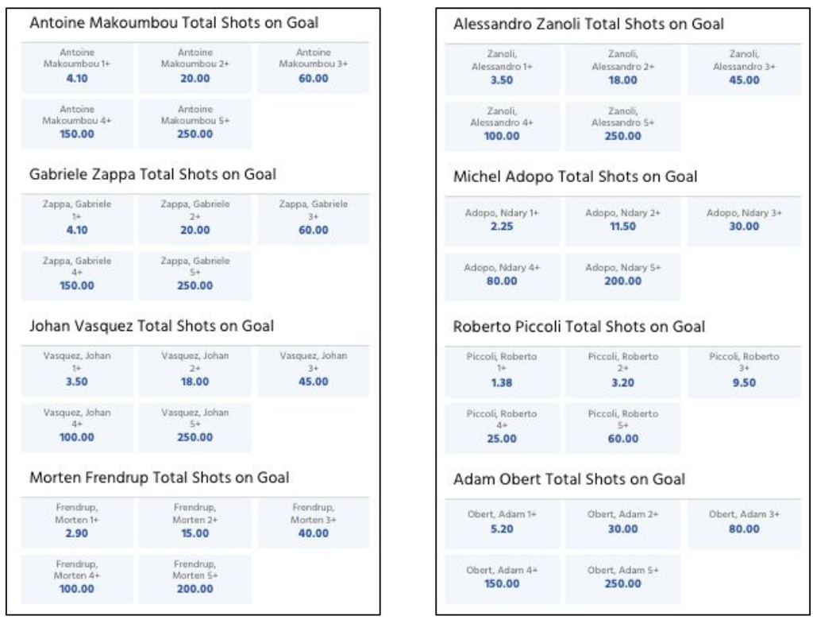

Figure 4: Data of 8 players’ shots on goal used to price the markets

```r
knitr::include_graphics("Fig/Shots on goal.png")
```

1)Given the following odds for 8 players, price the market “Most Shots on Goal in the Match”

**Answer:**

*In this problem, I first calculated the implied probabilities of each player taking between 1 and 5 shots on target and summed them. Then, I normalized these probabilities with respect to their total sum and calculated the odds by adding the overround.*

```r
players_Odd <- data.frame(
  Player = c("Antoine","Gabriele","Johan","Morten","Alessandro","Michel","Roberto","Adam"),
  Odds1 = c(4.10, 4.10, 3.50, 2.90, 3.50, 2.25, 1.38, 5.20),
  Odds2 = c(20.00, 20.00, 18.00, 15.00, 18.00, 11.50, 3.20, 30.00),
  Odds3 = c(60.00, 60.00, 45.00, 40.00, 45.00, 30.00, 9.50, 80.00),
  Odds4 = c(150.00, 150.00, 100.00, 100.00, 100.00, 80.00, 25.00, 150.00),
  Odds5 = c(250.00, 250.00, 250.00, 200.00, 250.00, 200.00, 60.00, 250.00)
)

Players_Prob <- players_Odd |>
  mutate(
    Prob1 = round(1 / Odds1/ 1.05, 4),
    Prob2 = round(1 / Odds2/ 1.05, 4),
    Prob3 = round(1 / Odds3/ 1.05, 4),
    Prob4 = round(1 / Odds4/ 1.05, 4),
    Prob5 = round(1 / Odds5/ 1.05, 4),
    Total_Prob = Prob1 + Prob2 + Prob3 + Prob4 + Prob5,
    normalized_Prob = round(Total_Prob / sum(Total_Prob),4),
    Odds = round(1 / (normalized_Prob * 1.05), 2)
  ) |> select(Player, Prob1, Prob2, Prob3, Prob4, Prob5, Total_Prob,
              normalized_Prob, Odds)


kable(Players_Prob, caption = "Players' Implied Probabilities for Shots on Goal")
```

Table 9: Players’ Implied Probabilities for Shots on Goal

| Player | Prob1 | Prob2 | Prob3 | Prob4 | Prob5 | Total_Prob | normalized_Prob | Odds |
| --- | --- | --- | --- | --- | --- | --- | --- | --- |
| Antoine | 0.2323 | 0.0476 | 0.0159 | 0.0063 | 0.0038 | 0.3059 | 0.0828 | 11.50 |
| Gabriele | 0.2323 | 0.0476 | 0.0159 | 0.0063 | 0.0038 | 0.3059 | 0.0828 | 11.50 |
| Johan | 0.2721 | 0.0529 | 0.0212 | 0.0095 | 0.0038 | 0.3595 | 0.0973 | 9.79 |
| Morten | 0.3284 | 0.0635 | 0.0238 | 0.0095 | 0.0048 | 0.4300 | 0.1164 | 8.18 |
| Alessandro | 0.2721 | 0.0529 | 0.0212 | 0.0095 | 0.0038 | 0.3595 | 0.0973 | 9.79 |
| Michel | 0.4233 | 0.0828 | 0.0317 | 0.0119 | 0.0048 | 0.5545 | 0.1501 | 6.34 |
| Roberto | 0.6901 | 0.2976 | 0.1003 | 0.0381 | 0.0159 | 1.1420 | 0.3091 | 3.08 |
| Adam | 0.1832 | 0.0317 | 0.0119 | 0.0063 | 0.0038 | 0.2369 | 0.0641 | 14.86 |

2)Pick two players and price the markets “Combined Shots on Goal 1+, 2+, 3+, 4+, 5+”

**Answer:**

*I selected the players Roberto and Michel to calculate the combined probabilities of shots on target. To simplify the calculation, I assumed independence between the events and a 5% overround.*

```r
R <- Players_Prob |> filter(Player == "Roberto")
M <- Players_Prob |> filter(Player == "Michel")

pR1 <- R$Prob1; pR2 <- R$Prob2; pR3 <- R$Prob3; pR4 <- R$Prob4; pR5 <- R$Prob5
pM1 <- M$Prob1; pM2 <- M$Prob2; pM3 <- M$Prob3; pM4 <- M$Prob4; pM5 <- M$Prob5

# -------------------------------
# 3. Combined probabilities
# -------------------------------

P_comb_1 <- pR1 + pM1 - pR1 * pM1

P_comb_2 <- pR2 + pM2 +
            pR1 * pM1 -
            pR2 * pM1 -
            pR1 * pM2

P_comb_3 <- pR3 + pM3 +
            pR2 * pM1 +
            pR1 * pM2

P_comb_4 <- pR4 + pM4 +
            pR3 * pM1 +
            pR1 * pM3 +
            pR2 * pM2

P_comb_5 <- pR5 + pM5 +
            pR4 * pM1 +
            pR1 * pM4 +
            pR3 * pM2 +
            pR2 * pM3

# -------------------------------
# 4. Tabela final
# -------------------------------

Combined_Market <- data.frame(
  Market = paste0("Combined ", 1:5, "+"),
  Probability = round(c(
    P_comb_1,
    P_comb_2,
    P_comb_3,
    P_comb_4,
    P_comb_5
  ), 4),
  Fair_Odds = round(1 / 1.05 / c(
    P_comb_1,
    P_comb_2,
    P_comb_3,
    P_comb_4,
    P_comb_5
  ), 2)
)

  kable(Combined_Market, caption = "Combined Shots on Goal Market for Roberto and Michel")
```

Table 10: Combined Shots on Goal Market for Roberto and Michel

| Market | Probability | Fair_Odds |
| --- | --- | --- |
| Combined 1+ | 0.8213 | 1.16 |
| Combined 2+ | 0.4894 | 1.95 |
| Combined 3+ | 0.3151 | 3.02 |
| Combined 4+ | 0.1390 | 6.85 |
| Combined 5+ | 0.0628 | 15.17 |

# References

- ESPN Analytics. (2026). NBA win probability model. ESPN. https://www.espn.com/nba/ (Acesso em 12 de janeiro de 2026)
- Figueiredo, N. N. de. (2023). Análise estatística do Campeonato Brasileiro de Futebol: 2017–2022 [Trabalho de Conclusão de Curso]. Universidade Federal de Alfenas. https://www.unifal-mg.edu.br/matematica/wp-content/uploads/sites/48/2024/07/TCC_Nikolas.pdf
- Meteostat. (2026). Meteostat: The Weather’s record keeper [Conjunto de repositórios de código aberto]. GitHub. https://github.com/meteostat
- Shufinskiy, V. (2025). nba_data: NBA play-by-play data from stats.nba.com, data.nba.com, pbpstats.com, and shots information [Repositório de dados]. GitHub. https://github.com/shufinskiy/nba_data
- UEFA. (2026). Match statistics and analysis. UEFA. https://www.uefa.com/uefanationsleague/teams/39--england/statistics/ (Acesso em 12 de janeiro de 2026)